# Clustering assignment

### 1. Import the libraries and load the data.

```python
import pandas as pd
import numpy as np
import matplotlib.pyplot as plt
import seaborn as sns
import warnings
warnings.filterwarnings('ignore')
%matplotlib inline
```

```python
#load the dataset
data=pd.read_csv("KAG_conversion_data")
data.head()
```

|  | ad_id | xyz_campaign_id | fb_campaign_id | age | gender | interest | Impressions | Clicks | Spent | Total_Conversion | Approved_Conversion |
| --- | --- | --- | --- | --- | --- | --- | --- | --- | --- | --- | --- |
| 0 | 708746 | 916 | 103916 | 30-34 | M | 15 | 7350 | 1 | 1.43 | 2 | 1 |
| 1 | 708749 | 916 | 103917 | 30-34 | M | 16 | 17861 | 2 | 1.82 | 2 | 0 |
| 2 | 708771 | 916 | 103920 | 30-34 | M | 20 | 693 | 0 | 0.00 | 1 | 0 |
| 3 | 708815 | 916 | 103928 | 30-34 | M | 28 | 4259 | 1 | 1.25 | 1 | 0 |
| 4 | 708818 | 916 | 103928 | 30-34 | M | 28 | 4133 | 1 | 1.29 | 1 | 1 |

```python
data.info()
```

```
<class 'pandas.core.frame.DataFrame'>
RangeIndex: 1143 entries, 0 to 1142
Data columns (total 11 columns):
 #   Column               Non-Null Count  Dtype
---  ------               --------------  -----
 0   ad_id                1143 non-null   int64
 1   xyz_campaign_id      1143 non-null   int64
 2   fb_campaign_id       1143 non-null   int64
 3   age                  1143 non-null   object
 4   gender               1143 non-null   object
 5   interest             1143 non-null   int64
 6   Impressions          1143 non-null   int64
 7   Clicks               1143 non-null   int64
 8   Spent                1143 non-null   float64
 9   Total_Conversion     1143 non-null   int64
 10  Approved_Conversion  1143 non-null   int64
dtypes: float64(1), int64(8), object(2)
memory usage: 98.4+ KB
```

```python
data.isnull().sum()
```

```
ad_id                  0
xyz_campaign_id        0
fb_campaign_id         0
age                    0
gender                 0
interest               0
Impressions            0
Clicks                 0
Spent                  0
Total_Conversion       0
Approved_Conversion    0
dtype: int64
```

```python
data.columns
```

```
Index(['ad_id', 'xyz_campaign_id', 'fb_campaign_id', 'age', 'gender',
       'interest', 'Impressions', 'Clicks', 'Spent', 'Total_Conversion',
       'Approved_Conversion'],
      dtype='object')
```

```python
data.shape
```

```
(1143, 11)
```

```python
data.describe()
```

|  | ad_id | xyz_campaign_id | fb_campaign_id | interest | Impressions | Clicks | Spent | Total_Conversion | Approved_Conversion |
| --- | --- | --- | --- | --- | --- | --- | --- | --- | --- |
| count | 1.143000e+03 | 1143.000000 | 1143.000000 | 1143.000000 | 1.143000e+03 | 1143.000000 | 1143.000000 | 1143.000000 | 1143.000000 |
| mean | 9.872611e+05 | 1067.382327 | 133783.989501 | 32.766404 | 1.867321e+05 | 33.390201 | 51.360656 | 2.855643 | 0.944007 |
| std | 1.939928e+05 | 121.629393 | 20500.308622 | 26.952131 | 3.127622e+05 | 56.892438 | 86.908418 | 4.483593 | 1.737708 |
| min | 7.087460e+05 | 916.000000 | 103916.000000 | 2.000000 | 8.700000e+01 | 0.000000 | 0.000000 | 0.000000 | 0.000000 |
| 25% | 7.776325e+05 | 936.000000 | 115716.000000 | 16.000000 | 6.503500e+03 | 1.000000 | 1.480000 | 1.000000 | 0.000000 |
| 50% | 1.121185e+06 | 1178.000000 | 144549.000000 | 25.000000 | 5.150900e+04 | 8.000000 | 12.370000 | 1.000000 | 1.000000 |
| 75% | 1.121804e+06 | 1178.000000 | 144657.500000 | 31.000000 | 2.217690e+05 | 37.500000 | 60.025000 | 3.000000 | 1.000000 |
| max | 1.314415e+06 | 1178.000000 | 179982.000000 | 114.000000 | 3.052003e+06 | 421.000000 | 639.949998 | 60.000000 | 21.000000 |

```python
data.head()
```

|  | ad_id | xyz_campaign_id | fb_campaign_id | age | gender | interest | Impressions | Clicks | Spent | Total_Conversion | Approved_Conversion |
| --- | --- | --- | --- | --- | --- | --- | --- | --- | --- | --- | --- |
| 0 | 708746 | 916 | 103916 | 30-34 | M | 15 | 7350 | 1 | 1.43 | 2 | 1 |
| 1 | 708749 | 916 | 103917 | 30-34 | M | 16 | 17861 | 2 | 1.82 | 2 | 0 |
| 2 | 708771 | 916 | 103920 | 30-34 | M | 20 | 693 | 0 | 0.00 | 1 | 0 |
| 3 | 708815 | 916 | 103928 | 30-34 | M | 28 | 4259 | 1 | 1.25 | 1 | 0 |
| 4 | 708818 | 916 | 103928 | 30-34 | M | 28 | 4133 | 1 | 1.29 | 1 | 1 |

```python
#change the data types
data["gender"] = data["gender"].astype('category')
data["age"] = data["age"].astype('category')
data["Spent"] = data["Spent"].astype('category')
data.dtypes
```

```
ad_id                     int64
xyz_campaign_id           int64
fb_campaign_id            int64
age                    category
gender                 category
interest                  int64
Impressions               int64
Clicks                    int64
Spent                  category
Total_Conversion          int64
Approved_Conversion       int64
dtype: object
```

### 2. Dummy encode any categorical or object values in the data and save the resulting data frame to variable X.

```python
#encode the data
Gender=pd.get_dummies(data.gender,drop_first=True)
Gender.head()
```

|  | M |
| --- | --- |
| 0 | 1 |
| 1 | 1 |
| 2 | 1 |
| 3 | 1 |
| 4 | 1 |

```python
#merge the datasets
X=pd.concat([data,Gender],axis="columns")
X.head()
```

|  | ad_id | xyz_campaign_id | fb_campaign_id | age | gender | interest | Impressions | Clicks | Spent | Total_Conversion | Approved_Conversion | M |
| --- | --- | --- | --- | --- | --- | --- | --- | --- | --- | --- | --- | --- |
| 0 | 708746 | 916 | 103916 | 30-34 | M | 15 | 7350 | 1 | 1.43 | 2 | 1 | 1 |
| 1 | 708749 | 916 | 103917 | 30-34 | M | 16 | 17861 | 2 | 1.82 | 2 | 0 | 1 |
| 2 | 708771 | 916 | 103920 | 30-34 | M | 20 | 693 | 0 | 0.00 | 1 | 0 | 1 |
| 3 | 708815 | 916 | 103928 | 30-34 | M | 28 | 4259 | 1 | 1.25 | 1 | 0 | 1 |
| 4 | 708818 | 916 | 103928 | 30-34 | M | 28 | 4133 | 1 | 1.29 | 1 | 1 | 1 |

```python
#change the data types
data["gender"] = data["gender"].astype('category')
data["age"] = data["age"].astype('category')
data["Spent"] = data["Spent"].astype('category')
data.dtypes
```

```
ad_id                     int64
xyz_campaign_id           int64
fb_campaign_id            int64
age                    category
gender                 category
interest                  int64
Impressions               int64
Clicks                    int64
Spent                  category
Total_Conversion          int64
Approved_Conversion       int64
dtype: object
```

```python
#categorical data
categorical_data = X.drop(["M","ad_id","xyz_campaign_id","fb_campaign_id","interest","Impressions","Clicks","Total_Conversion","Approved_Conversion"],axis=1)
categorical_data.head()
```

|  | age | gender | Spent |
| --- | --- | --- | --- |
| 0 | 30-34 | M | 1.43 |
| 1 | 30-34 | M | 1.82 |
| 2 | 30-34 | M | 0.00 |
| 3 | 30-34 | M | 1.25 |
| 4 | 30-34 | M | 1.29 |

```python
data["age"] = data["age"].astype('category')
data["gender"] = data["gender"].astype('category')
data["Spent"] = data["Spent"].astype('category')
data.dtypes
```

```
ad_id                     int64
xyz_campaign_id           int64
fb_campaign_id            int64
age                    category
gender                 category
interest                  int64
Impressions               int64
Clicks                    int64
Spent                  category
Total_Conversion          int64
Approved_Conversion       int64
dtype: object
```

```python
categorical_data["age_cat"]= categorical_data["age"].cat.codes
categorical_data["gender_cat"]=categorical_data["gender"].cat.codes
categorical_data["Spent_cat"]=categorical_data["Spent"].cat.codes
categorical_data.head()
```

|  | age | gender | Spent | age_cat | gender_cat | Spent_cat |
| --- | --- | --- | --- | --- | --- | --- |
| 0 | 30-34 | M | 1.43 | 0 | 1 | 46 |
| 1 | 30-34 | M | 1.82 | 0 | 1 | 73 |
| 2 | 30-34 | M | 0.00 | 0 | 1 | 0 |
| 3 | 30-34 | M | 1.25 | 0 | 1 | 30 |
| 4 | 30-34 | M | 1.29 | 0 | 1 | 34 |

```python
df=pd.concat([categorical_data,data],axis="columns")
df.head()
```

|  | age | gender | Spent | age_cat | gender_cat | Spent_cat | ad_id | xyz_campaign_id | fb_campaign_id | age | gender | interest | Impressions | Clicks | Spent | Total_Conversion | Approved_Conversion |
| --- | --- | --- | --- | --- | --- | --- | --- | --- | --- | --- | --- | --- | --- | --- | --- | --- | --- |
| 0 | 30-34 | M | 1.43 | 0 | 1 | 46 | 708746 | 916 | 103916 | 30-34 | M | 15 | 7350 | 1 | 1.43 | 2 | 1 |
| 1 | 30-34 | M | 1.82 | 0 | 1 | 73 | 708749 | 916 | 103917 | 30-34 | M | 16 | 17861 | 2 | 1.82 | 2 | 0 |
| 2 | 30-34 | M | 0.00 | 0 | 1 | 0 | 708771 | 916 | 103920 | 30-34 | M | 20 | 693 | 0 | 0.00 | 1 | 0 |
| 3 | 30-34 | M | 1.25 | 0 | 1 | 30 | 708815 | 916 | 103928 | 30-34 | M | 28 | 4259 | 1 | 1.25 | 1 | 0 |
| 4 | 30-34 | M | 1.29 | 0 | 1 | 34 | 708818 | 916 | 103928 | 30-34 | M | 28 | 4133 | 1 | 1.29 | 1 | 1 |

```python
df.isnull().sum()
```

```
age                    0
gender                 0
Spent                  0
age_cat                0
gender_cat             0
Spent_cat              0
ad_id                  0
xyz_campaign_id        0
fb_campaign_id         0
age                    0
gender                 0
interest               0
Impressions            0
Clicks                 0
Spent                  0
Total_Conversion       0
Approved_Conversion    0
dtype: int64
```

### 3. Using a heat map to show the correlation in the data.

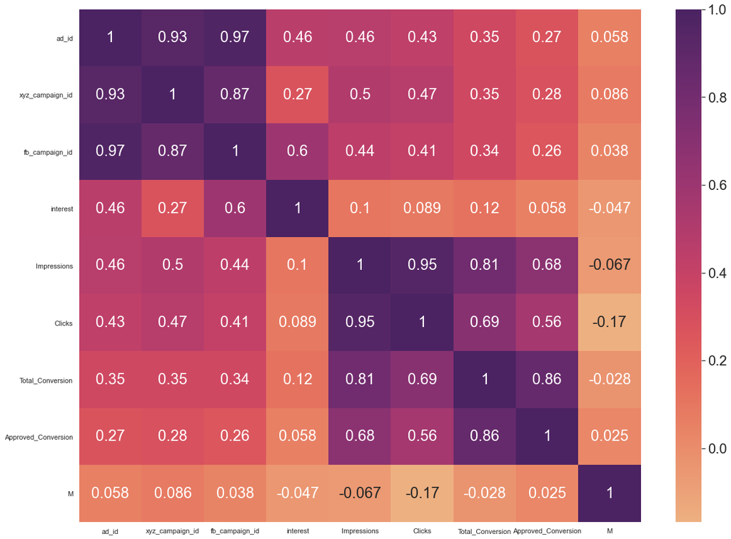

```python
plt.subplots(figsize=(20,15))
sns.set(font_scale=2.0)
sns.heatmap(X.corr(),annot=True,cmap="flare")
```

#### 3a. Drop the first 4 columns in the data frame X.

```python
X.head()
```

|  | ad_id | xyz_campaign_id | fb_campaign_id | age | gender | interest | Impressions | Clicks | Spent | Total_Conversion | Approved_Conversion | M |
| --- | --- | --- | --- | --- | --- | --- | --- | --- | --- | --- | --- | --- |
| 0 | 708746 | 916 | 103916 | 30-34 | M | 15 | 7350 | 1 | 1.43 | 2 | 1 | 1 |
| 1 | 708749 | 916 | 103917 | 30-34 | M | 16 | 17861 | 2 | 1.82 | 2 | 0 | 1 |
| 2 | 708771 | 916 | 103920 | 30-34 | M | 20 | 693 | 0 | 0.00 | 1 | 0 | 1 |
| 3 | 708815 | 916 | 103928 | 30-34 | M | 28 | 4259 | 1 | 1.25 | 1 | 0 | 1 |
| 4 | 708818 | 916 | 103928 | 30-34 | M | 28 | 4133 | 1 | 1.29 | 1 | 1 | 1 |

```python
X.drop(["ad_id","xyz_campaign_id","fb_campaign_id","age"], axis=1, inplace=True)
X.head()
```

|  | gender | interest | Impressions | Clicks | Spent | Total_Conversion | Approved_Conversion | M |
| --- | --- | --- | --- | --- | --- | --- | --- | --- |
| 0 | M | 15 | 7350 | 1 | 1.43 | 2 | 1 | 1 |
| 1 | M | 16 | 17861 | 2 | 1.82 | 2 | 0 | 1 |
| 2 | M | 20 | 693 | 0 | 0.00 | 1 | 0 | 1 |
| 3 | M | 28 | 4259 | 1 | 1.25 | 1 | 0 | 1 |
| 4 | M | 28 | 4133 | 1 | 1.29 | 1 | 1 | 1 |

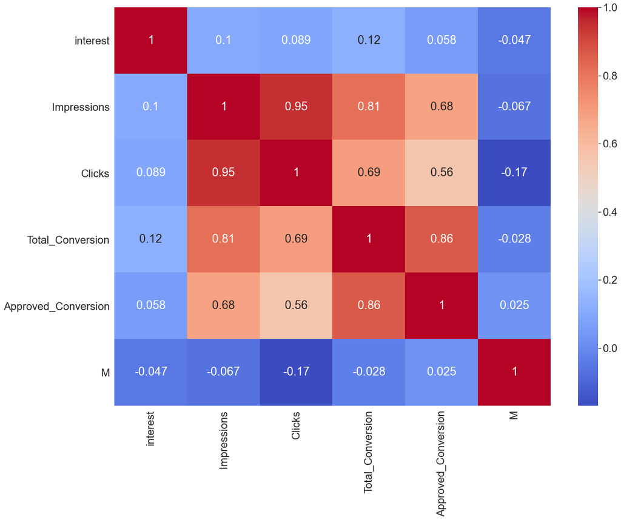

```python
plt.subplots(figsize=(20,15))
sns.set(font_scale=2.0)
sns.heatmap(X.corr(),annot=True,cmap="coolwarm")
```

### 4. Using the elbow method:

```python
from sklearn.cluster import KMeans
km = KMeans(n_clusters=4)
```

```python
# Prep
xfeatures = df[["Total_Conversion","Approved_Conversion"]]
```

```python
# Fit n Predict
clusters = km.fit_predict(xfeatures)
```

```python
# Get all the Labels(Clusters)
km.labels_
```

```
array([0, 0, 0, ..., 0, 2, 2])
```

```python
clusters
```

```
array([0, 0, 0, ..., 0, 2, 2])
```

```python
# Check if predicted clusters is the same as our labels
clusters is km.labels_
```

```
True
```

#### b. Also include the graphical plot for the elbow curve.

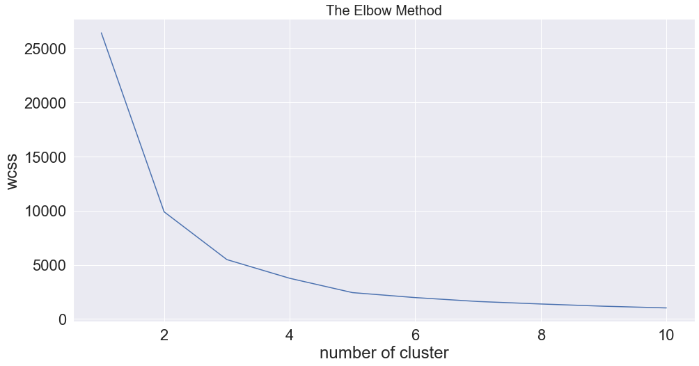

```python
from sklearn.cluster import KMeans
plt.figure(figsize=(16,8))
wcss = []
for i in range(1, 11):
    km = KMeans(n_clusters = i, init = 'k-means++', max_iter = 300, n_init = 10, random_state = 0)
    km.fit(xfeatures)
    wcss.append(km.inertia_)

plt.plot(range(1,11), wcss)
plt.title("The Elbow Method", fontsize = 20)
plt.xlabel("number of cluster")
plt.ylabel("wcss")
plt.show()
```

### 5.Based on the result above in 4b use the value at your elbow point to cluster the values in the data frame X.

```python
X.head()
```

|  | gender | interest | Impressions | Clicks | Spent | Total_Conversion | Approved_Conversion | M |
| --- | --- | --- | --- | --- | --- | --- | --- | --- |
| 0 | M | 15 | 7350 | 1 | 1.43 | 2 | 1 | 1 |
| 1 | M | 16 | 17861 | 2 | 1.82 | 2 | 0 | 1 |
| 2 | M | 20 | 693 | 0 | 0.00 | 1 | 0 | 1 |
| 3 | M | 28 | 4259 | 1 | 1.25 | 1 | 0 | 1 |
| 4 | M | 28 | 4133 | 1 | 1.29 | 1 | 1 | 1 |

```python
X.drop(["M"], axis='columns', inplace=True)
X.head()
```

|  | gender | interest | Impressions | Clicks | Spent | Total_Conversion | Approved_Conversion |
| --- | --- | --- | --- | --- | --- | --- | --- |
| 0 | M | 15 | 7350 | 1 | 1.43 | 2 | 1 |
| 1 | M | 16 | 17861 | 2 | 1.82 | 2 | 0 |
| 2 | M | 20 | 693 | 0 | 0.00 | 1 | 0 |
| 3 | M | 28 | 4259 | 1 | 1.25 | 1 | 0 |
| 4 | M | 28 | 4133 | 1 | 1.29 | 1 | 1 |

```python
from sklearn.cluster import KMeans
km = KMeans(n_clusters=3)
```

```python
#Prep
xfeatures = X[["Total_Conversion","Approved_Conversion"]]
```

```python
# Fit n Predict
clusters = km.fit_predict(xfeatures)
```

```python
# Get all the Labels(Clusters)
km.labels_
```

```
array([0, 0, 0, ..., 0, 2, 0])
```

```python
clusters
```

```
array([0, 0, 0, ..., 0, 2, 0])
```

```python
# Check if predicted clusters is the same as our labels
clusters is km.labels_
```

```
True
```

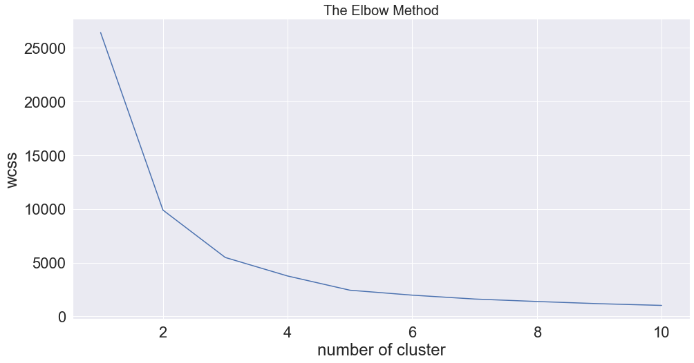

```python
from sklearn.cluster import KMeans
plt.figure(figsize=(16,8))
wcss = []
for i in range(1, 11):
    km = KMeans(n_clusters = i, init = 'k-means++', max_iter = 300, n_init = 10, random_state = 0)
    km.fit(xfeatures)
    wcss.append(km.inertia_)

plt.plot(range(1,11), wcss)
plt.title("The Elbow Method", fontsize = 20)
plt.xlabel("number of cluster")
plt.ylabel("wcss")
plt.show()
```

### 6.Use the model to predict the labels from the data and save them to variable y_means.

```python
from sklearn.cluster import KMeans
km=KMeans(n_clusters=3)
km
```

```
KMeans(n_clusters=3)
```

```python
#Fit n Predict
clusters = km.fit_predict(xfeatures)
```

```python
y_means=km.fit_predict(df[["Spent_cat","interest"]])
y_means
```

```
array([0, 0, 0, ..., 2, 1, 1])
```

#### 7.Add the values in y_means to the original data frame (not X) as column ‘Advert_Type’

```python
df["Advert_Type"]=y_means
df.head()
```

|  | age | gender | Spent | age_cat | gender_cat | Spent_cat | ad_id | xyz_campaign_id | fb_campaign_id | age | gender | interest | Impressions | Clicks | Spent | Total_Conversion | Approved_Conversion | Advert_Type |
| --- | --- | --- | --- | --- | --- | --- | --- | --- | --- | --- | --- | --- | --- | --- | --- | --- | --- | --- |
| 0 | 30-34 | M | 1.43 | 0 | 1 | 46 | 708746 | 916 | 103916 | 30-34 | M | 15 | 7350 | 1 | 1.43 | 2 | 1 | 0 |
| 1 | 30-34 | M | 1.82 | 0 | 1 | 73 | 708749 | 916 | 103917 | 30-34 | M | 16 | 17861 | 2 | 1.82 | 2 | 0 | 0 |
| 2 | 30-34 | M | 0.00 | 0 | 1 | 0 | 708771 | 916 | 103920 | 30-34 | M | 20 | 693 | 0 | 0.00 | 1 | 0 | 0 |
| 3 | 30-34 | M | 1.25 | 0 | 1 | 30 | 708815 | 916 | 103928 | 30-34 | M | 28 | 4259 | 1 | 1.25 | 1 | 0 | 0 |
| 4 | 30-34 | M | 1.29 | 0 | 1 | 34 | 708818 | 916 | 103928 | 30-34 | M | 28 | 4133 | 1 | 1.29 | 1 | 1 | 0 |

### 8.Using any form of distribution plot of your choice and the original data frame, plot 2 graphs that can be used to answer the following:

##### a.Which advert type lead to the highest and consistent amount of sales by customers of all the age brackets?

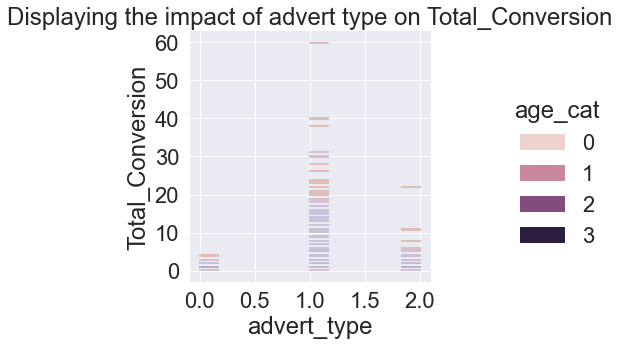

```python
import seaborn as sns
import matplotlib.pyplot as plt

sns.displot(df, x="Advert_Type", y="Total_Conversion", hue="age_cat", kind="hist")
plt.title("Displaying the impact of advert type on Total_Conversion")
plt.xlabel("advert_type")
plt.ylabel("Total_Conversion")
sns.set_palette("husl")
sns.set(rc={'figure.figsize':(30,20)})

plt.show()
```

##### b.Does the company xyz have gender bias in terms of their ad spending? Are their products gender neutral?

[figure not shown]

```python
import seaborn as sns
import matplotlib.pyplot as plt

sns.displot(df, x="Advert_Type", y="Total_Conversion", hue="gender_cat", kind="hist")
plt.title("")
plt.xlabel("advert_type")
plt.ylabel("Approved_Conversion")
sns.set_palette("husl")
sns.set(rc={'figure.figsize':(30,20)})

plt.show()
```

### 9.Perform the same analysis using hierarchical clustering and compare the results in terms of the number of useable clusters.

```python
df.drop(["age","Spent_cat","gender"],axis=1, inplace=True)
df.head()
```

|  | Spent | age_cat | gender_cat | ad_id | xyz_campaign_id | fb_campaign_id | interest | Impressions | Clicks | Spent | Total_Conversion | Approved_Conversion |
| --- | --- | --- | --- | --- | --- | --- | --- | --- | --- | --- | --- | --- |
| 0 | 1.43 | 0 | 1 | 708746 | 916 | 103916 | 15 | 7350 | 1 | 1.43 | 2 | 1 |
| 1 | 1.82 | 0 | 1 | 708749 | 916 | 103917 | 16 | 17861 | 2 | 1.82 | 2 | 0 |
| 2 | 0.00 | 0 | 1 | 708771 | 916 | 103920 | 20 | 693 | 0 | 0.00 | 1 | 0 |
| 3 | 1.25 | 0 | 1 | 708815 | 916 | 103928 | 28 | 4259 | 1 | 1.25 | 1 | 0 |
| 4 | 1.29 | 0 | 1 | 708818 | 916 | 103928 | 28 | 4133 | 1 | 1.29 | 1 | 1 |

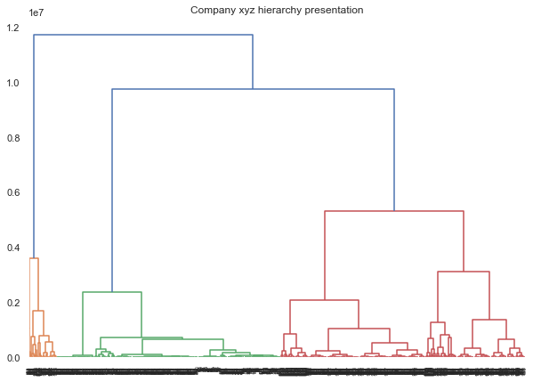

```python
import scipy.cluster.hierarchy as shc

plt.figure(figsize=(10,7))
plt.title("Company xyz hierarchy presentation")
dend = shc.dendrogram(shc.linkage(df, method='ward'))
```